# Statistisk databehandling MT4007-HT22

## Basic `readr`

## Functions `tibble` and `read_*`

- The `read_*` functions are extremely clever, helping you read data and *always* returning a `tibble`.
- A `tibble` is a “nicer” and more honest `data.frame`
- Will this turn out as you imagined?

```r
data.frame(x=list("="="=", "B"="b"), # length 2
           y=c(1,2,3)) # length 3
tibble(x=list("="="=", "B"="b"),
       y=c(1,2,3))

data.frame(x=list("A"="a", "B"="b"),
           y=list("C"="c", "D"="d"))
tibble(x=list("A"="a", "B"="b"),
       y=list("C"="c", "D"="d"))
```

## `read_*`

- Faster than base-R `read.*`, used in the same way.
- Don’t make strings into factors.
- Nothing strange about your column names.
- Does not depend on environment variables in your system, good for reproducibility among machines/systems.
- Useful arguments `col_types` (`colClasses` from `read.*`) and `guess_max`
- We will complain if you use `read.csv` instead of `read_csv`

## `readxl::read_excel`

- Package `readxl`, excel files are special
- `readxl::read_excel` function to read `.xls`/ `.xlsx` files.
- Unique to `read_excel` the `sheet` argument.
- Will be used in Homework 2.

## Basic `dplyr`

## `arrange` arranges the rows in the data

```r
mtcars <- tibble::rownames_to_column(mtcars, var = "model")
kable(head(arrange(mtcars, mpg), n = 4))
```

| model | mpg | cyl | disp | hp | drat | wt | qsec | vs | am | gear | carb |
| --- | --- | --- | --- | --- | --- | --- | --- | --- | --- | --- | --- |
| Cadillac Fleetwood | 10.4 | 8 | 472 | 205 | 2.93 | 5.250 | 17.98 | 0 | 0 | 3 | 4 |
| Lincoln Continental | 10.4 | 8 | 460 | 215 | 3.00 | 5.424 | 17.82 | 0 | 0 | 3 | 4 |
| Camaro Z28 | 13.3 | 8 | 350 | 245 | 3.73 | 3.840 | 15.41 | 0 | 0 | 3 | 4 |
| Duster 360 | 14.3 | 8 | 360 | 245 | 3.21 | 3.570 | 15.84 | 0 | 0 | 3 | 4 |

## `arrange` arranges the rows in the data

```r
kable(head(arrange(mtcars, mpg, disp), n = 4))
```

| model | mpg | cyl | disp | hp | drat | wt | qsec | vs | am | gear | carb |
| --- | --- | --- | --- | --- | --- | --- | --- | --- | --- | --- | --- |
| Lincoln Continental | 10.4 | 8 | 460 | 215 | 3.00 | 5.424 | 17.82 | 0 | 0 | 3 | 4 |
| Cadillac Fleetwood | 10.4 | 8 | 472 | 205 | 2.93 | 5.250 | 17.98 | 0 | 0 | 3 | 4 |
| Camaro Z28 | 13.3 | 8 | 350 | 245 | 3.73 | 3.840 | 15.41 | 0 | 0 | 3 | 4 |
| Duster 360 | 14.3 | 8 | 360 | 245 | 3.21 | 3.570 | 15.84 | 0 | 0 | 3 | 4 |

## `filter` select rows (observations)

```r
#only those with manual transmission
kable(head(filter(mtcars, am == 1), n=4))
```

| model | mpg | cyl | disp | hp | drat | wt | qsec | vs | am | gear | carb |
| --- | --- | --- | --- | --- | --- | --- | --- | --- | --- | --- | --- |
| Mazda RX4 | 21.0 | 6 | 160.0 | 110 | 3.90 | 2.620 | 16.46 | 0 | 1 | 4 | 4 |
| Mazda RX4 Wag | 21.0 | 6 | 160.0 | 110 | 3.90 | 2.875 | 17.02 | 0 | 1 | 4 | 4 |
| Datsun 710 | 22.8 | 4 | 108.0 | 93 | 3.85 | 2.320 | 18.61 | 1 | 1 | 4 | 1 |
| Fiat 128 | 32.4 | 4 | 78.7 | 66 | 4.08 | 2.200 | 19.47 | 1 | 1 | 4 | 1 |

## `filter` select rows (observations)

```r
kable(head(filter(mtcars, mpg < 30), n=4))
```

| model | mpg | cyl | disp | hp | drat | wt | qsec | vs | am | gear | carb |
| --- | --- | --- | --- | --- | --- | --- | --- | --- | --- | --- | --- |
| Mazda RX4 | 21.0 | 6 | 160 | 110 | 3.90 | 2.620 | 16.46 | 0 | 1 | 4 | 4 |
| Mazda RX4 Wag | 21.0 | 6 | 160 | 110 | 3.90 | 2.875 | 17.02 | 0 | 1 | 4 | 4 |
| Datsun 710 | 22.8 | 4 | 108 | 93 | 3.85 | 2.320 | 18.61 | 1 | 1 | 4 | 1 |
| Hornet 4 Drive | 21.4 | 6 | 258 | 110 | 3.08 | 3.215 | 19.44 | 1 | 0 | 3 | 1 |

## `mutate` introduces new/transforms variable

```r
kable(head(mutate(mtcars, lpm = 235 / mpg), n=4))
```

| model | mpg | cyl | disp | hp | drat | wt | qsec | vs | am | gear | carb | lpm |
| --- | --- | --- | --- | --- | --- | --- | --- | --- | --- | --- | --- | --- |
| Mazda RX4 | 21.0 | 6 | 160 | 110 | 3.90 | 2.620 | 16.46 | 0 | 1 | 4 | 4 | 11.19048 |
| Mazda RX4 Wag | 21.0 | 6 | 160 | 110 | 3.90 | 2.875 | 17.02 | 0 | 1 | 4 | 4 | 11.19048 |
| Datsun 710 | 22.8 | 4 | 108 | 93 | 3.85 | 2.320 | 18.61 | 1 | 1 | 4 | 1 | 10.30702 |
| Hornet 4 Drive | 21.4 | 6 | 258 | 110 | 3.08 | 3.215 | 19.44 | 1 | 0 | 3 | 1 | 10.98131 |

## `select` selects variables (columns)

```r
kable(head(select(mtcars, model, mpg), n=4))
```

| model | mpg |
| --- | --- |
| Mazda RX4 | 21.0 |
| Mazda RX4 Wag | 21.0 |
| Datsun 710 | 22.8 |
| Hornet 4 Drive | 21.4 |

## Pipe `%>%`

What function does the argument `x=3` take?

```r
df <- f1(f2(f3(f4(mtcars, x=2), x), x=3))
```

*This is not easy to read!* How can we solve it?

[figure not shown]

## Pipe `%>%`

Determine \(h\circ g \circ f(a) = h(g(f(a)))\)

Three different ways to calculate this in R:

```
b <- f(a)
c <- g(b)
h(c)
```

```
h(g(f(a)))
```

```
a %>%
    f() %>%
    g() %>%
    h()
```

## Pipe `%>%`

```
mtcars <- mutate(mtcars, lpm = 235 / mpg)
mtcars <- filter(mtcars, am == 1)
ggplot(mtcars, aes(x = hp, y = lpm)) + geom_point()
```

```
ggplot(
    filter(
        mutate(mtcars, lpm = 235 / mpg)
        , am ==1),
    aes(x = hp, y = lpm)) + geom_point()
```

```
mtcars %>%
    mutate(lpm = 235 / mpg) %>%
    filter(am == 1) %>%
    ggplot(aes(x = hp, y = lpm)) + geom_point()
```

## Basic `ggplot2`

## `ggplot2`

A statistical plot has components

- `data`
- `geom`: type of geometric objects (points, lines, …)
- `cord`: coordinate system
- `mapping`: binds data to the dimensions/“aesthetics” of the coordinate system (position, color, shape, size, …)

## `ggplot2`

A scatterplot

- `data`: `mpg` and `hp` for a number of cars
- `geom`: points
- `coord`: Cartesian
- `mapping`: binds `hp` to position on the `x` axis and `mpg` to the `y` axis

## `ggplot2`

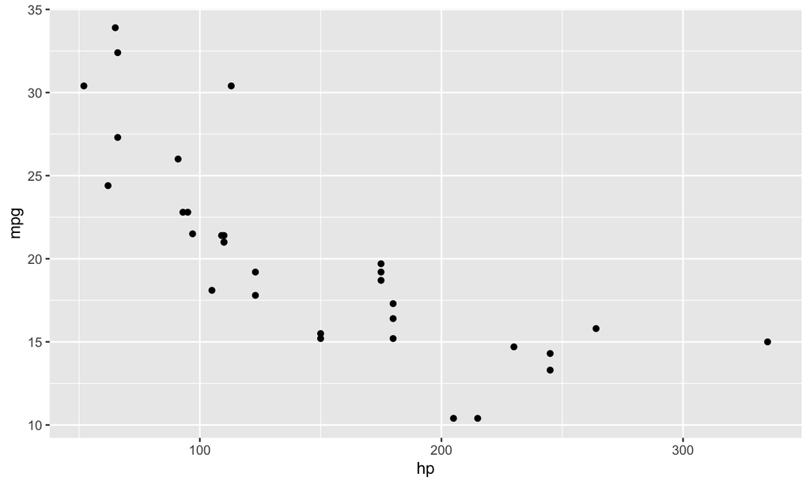

```r
ggplot(data = mtcars, mapping = aes(x = hp, y = mpg)) + geom_point()
```

## `ggplot2` with some color and sizes

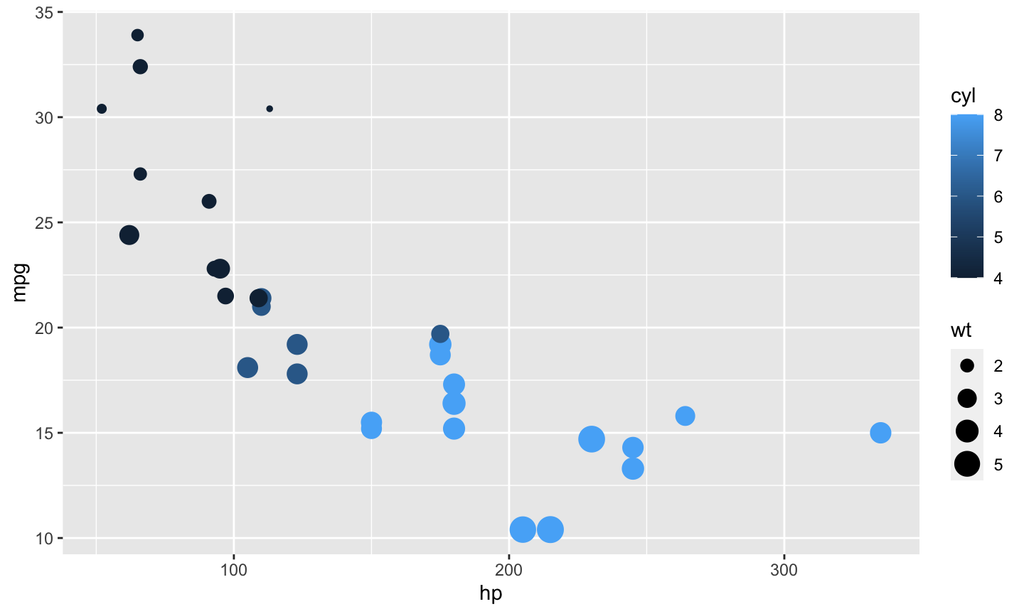

```r
ggplot(mtcars,
       aes(x = hp, y = mpg, size = wt, color = cyl)) +
    geom_point()
```

What is cyl?

## `ggplot2`: the types in `mtcars` matter!

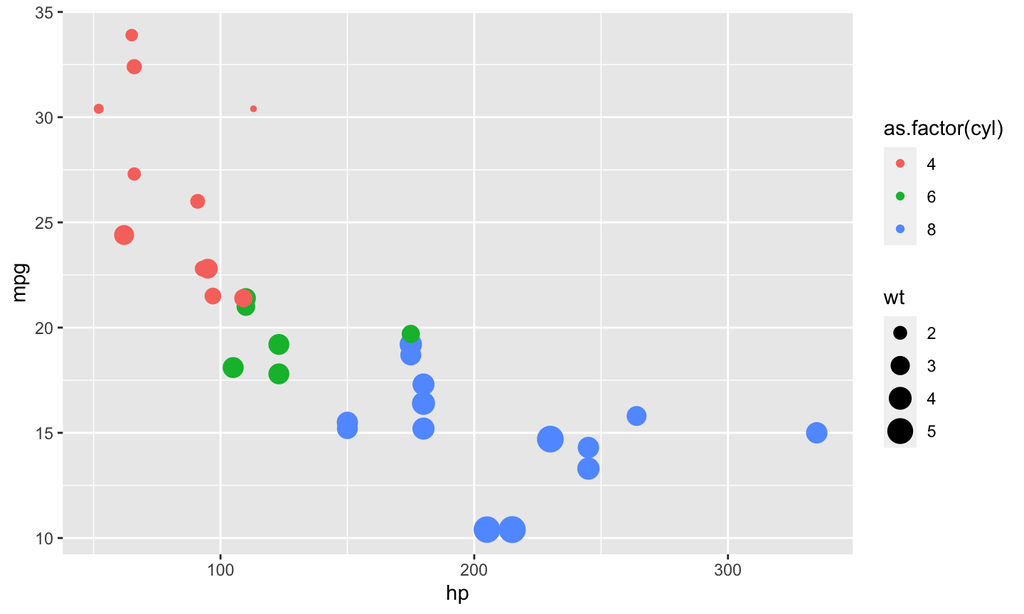

```r
ggplot(mtcars,
       aes(x = hp, y = mpg, size = wt, color = as.factor(cyl))) +
    geom_point()
```

## `ggplot2` arguments outside of `aes` but in a `geom`

```r
ggplot(mtcars,
       aes(x = hp, y = mpg, size = wt)) +
    geom_point(color = cyl)
# ERROR
```

```r
ggplot(mtcars,
       aes(x = hp, y = mpg, size = wt)) +
    geom_point(color = "red")
# OK
```

`aes` looks in `mtcars` but not `geom`!

## `ggplot2`

Be careful about reusing names in columns, variables, etc.

```r
cyl <- "blue"
ggplot(mtcars,
       aes(x = hp, y = mpg, size = wt)) +
    geom_point(color = cyl)
```

Error?